# Análise Bivariada para Variáveis Quantitativas

# Análise Bivariada para Variáveis Quantitativas

Neste notebook, vamos explorar a relação entre novas variáveis quantitativas criadas a partir da base `mtcars`.

## Carregando Pacotes Necessários

```r
library(tidyverse)
```

## Preparando a Base de Dados

Vamos criar novas variáveis a partir dos dados originais:

- `eficiencia_combustivel`: Eficiência de combustível em milhas por galão dividida pelo peso do carro.
- `potencia_ajustada`: Potência ajustada pelo número de cilindros.
- `velocidade_maxima`: Estimativa fictícia de velocidade máxima.
- `aceleracao`: Tempo estimado para acelerar de 0 a 100 km/h.

```r
glimpse(tb2)
```

```
Rows: 32
Columns: 15
$ mpg                    <dbl> 21.0, 21.0, 22.8, 21.4, 18.7, 18.1, 14.3, 24.4, 22.8, 19.2, 17.8, 16.4, 17.3, …
$ cyl                    <dbl> 6, 6, 4, 6, 8, 6, 8, 4, 4, 6, 6, 8, 8, 8, 8, 8, 8, 4, 4, 4, 4, 8, 8, 8, 8, 4, …
$ disp                   <dbl> 160.0, 160.0, 108.0, 258.0, 360.0, 225.0, 360.0, 146.7, 140.8, 167.6, 167.6, 2…
$ hp                     <dbl> 110, 110, 93, 110, 175, 105, 245, 62, 95, 123, 123, 180, 180, 180, 205, 215, 2…
$ drat                   <dbl> 3.90, 3.90, 3.85, 3.08, 3.15, 2.76, 3.21, 3.69, 3.92, 3.92, 3.92, 3.07, 3.07, …
$ wt                     <dbl> 2.620, 2.875, 2.320, 3.215, 3.440, 3.460, 3.570, 3.190, 3.150, 3.440, 3.440, 4…
$ qsec                   <dbl> 16.46, 17.02, 18.61, 19.44, 17.02, 20.22, 15.84, 20.00, 22.90, 18.30, 18.90, 1…
$ vs                     <dbl> 0, 0, 1, 1, 0, 1, 0, 1, 1, 1, 1, 0, 0, 0, 0, 0, 0, 1, 1, 1, 1, 0, 0, 0, 0, 1, …
$ am                     <dbl> 1, 1, 1, 0, 0, 0, 0, 0, 0, 0, 0, 0, 0, 0, 0, 0, 0, 1, 1, 1, 0, 0, 0, 0, 0, 1, …
$ gear                   <dbl> 4, 4, 4, 3, 3, 3, 3, 4, 4, 4, 4, 3, 3, 3, 3, 3, 3, 4, 4, 4, 3, 3, 3, 3, 3, 4, …
$ carb                   <dbl> 4, 4, 1, 1, 2, 1, 4, 2, 2, 4, 4, 3, 3, 3, 4, 4, 4, 1, 2, 1, 1, 2, 2, 4, 2, 1, …
$ eficiencia_combustivel <dbl> 8.015267, 7.304348, 9.827586, 6.656299, 5.436047, 5.231214, 4.005602, 7.648903…
$ potencia_ajustada      <dbl> 18.33333, 18.33333, 23.25000, 18.33333, 21.87500, 17.50000, 30.62500, 15.50000…
$ velocidade_maxima      <dbl> 125.95420, 114.78261, 120.25862, 102.64386, 152.61628, 91.04046, 205.88235, 58…
$ aceleracao             <dbl> 11.909091, 13.068182, 12.473118, 14.613636, 9.828571, 16.476190, 7.285714, 25.…
```

## Análise Bivariada e Mais

### Relação Entre Eficiência de Combustível e Potência Ajustada

Primeiro, vamos explorar a relação entre `eficiencia_combustivel` e `potencia_ajustada`.

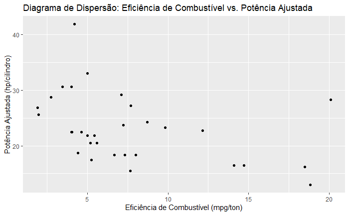

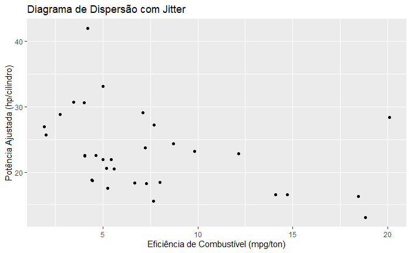

### Relação Entre Velocidade Máxima e Aceleração

Agora, vamos explorar a relação entre `velocidade_maxima` e `aceleracao`.

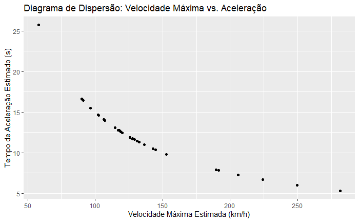

### Adicionando uma Terceira Variável

Podemos adicionar uma terceira variável ao gráfico, utilizando tamanho, cor ou transparência para representar essa variável. Vamos usar `mpg` (milhas por galão) como a terceira variável.

#### Tamanho dos Pontos

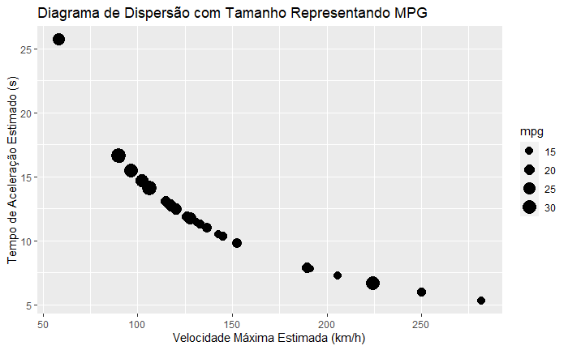

#### Transparência dos Pontos

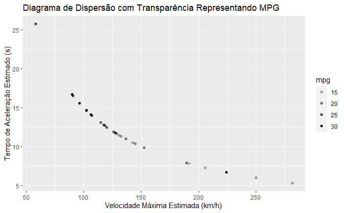

#### Cores Representando MPG

Podemos usar cores para representar a eficiência de combustível (`mpg`).

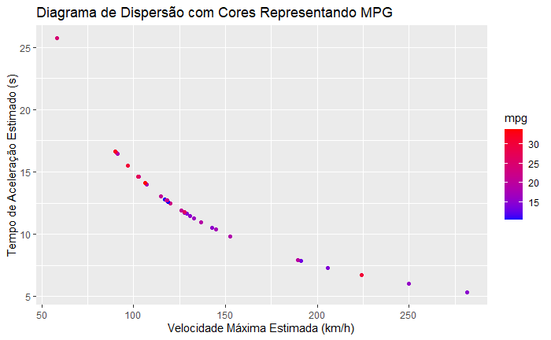

### Adicionando Linhas de Tendência

Podemos adicionar uma linha de tendência para mostrar a relação entre `velocidade_maxima` e `aceleracao`.

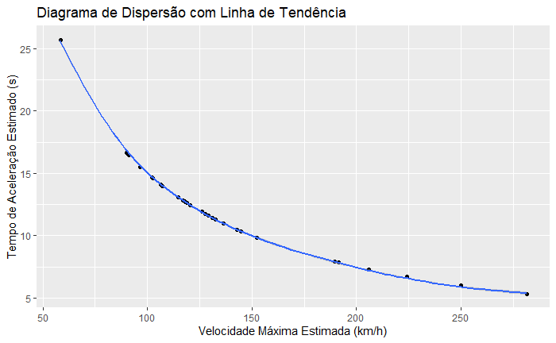

### Ajuste Polinomial

Podemos ajustar a linha de tendência com um polinômio de grau 3, por exemplo.

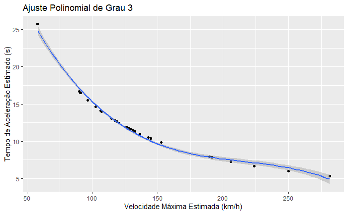

## Facetando Gráficos por Grupos

Vamos dividir os dados em facetas, para visualizar a relação `velocidade_maxima` e `aceleracao` separadamente para cada número de cilindros.

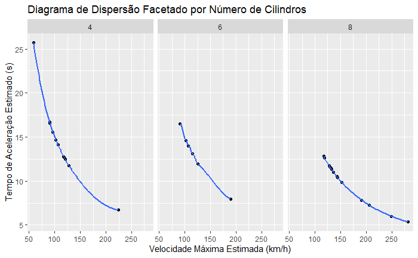

Podemos também facetar por faixas de eficiência de combustível (`mpg`).

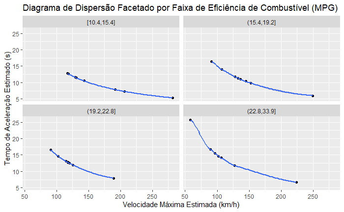